# Missing_Migrant_ML_Project

Raman Kadariya

Variable Name Description

- Web ID - An automatically generated number used to identify each unique entry in the dataset.
- Region of incident - The region in which an incident took place.
- Reported date - Estimated date of death.
- Reported year - The year in which the incident occurred.
- Reported month - The month in which the incident occurred.
- Number dead - The total number of people confirmed dead in one incident, i.e. the number of bodies recovered.
- Number missing - The total number of those who are missing and are thus assumed to be dead.
- Total dead and missing - The sum of the ‘number dead’ and ‘number missing’ variables.
- Number of survivors - The number of migrants that survived the incident, if known.
- Number of females - Indicates the number of females found dead or missing.
- Number of males - Indicates the number of males found dead or missing.
- Number of children - Indicates the number of individuals under the age of 18 found dead or missing.
- Age - The age of the decedent(s). Occasionally, an estimated age range is recorded.
- Country of origin - Country of birth of the decedent. If unknown, the entry will be marked “unknown”.
- Region of origin - Region of origin of the decedent(s).
- Cause of death - The determination of conditions resulting in the migrant’s death i.e. the circumstances of the event that produced the fatal injury.
- Location description - Place where the death(s) occurred or where the body or bodies were found.
- Location coordinates - Place where the death(s) occurred or where the body or bodies were found.
- Migration route - Name of the migrant route on which incident occurred, if known.
- UNSD geographical grouping - Geographical region in which the incident took place, as designated by the United Nations Statistics Division (UNSD) geoscheme.
- Information source - Name of source of information for each incident. Multiple sources may be listed.
- Link - Links to original reports of migrant deaths / disappearances if available. Multiple links may be listed.
- Source quality - Incidents are ranked on a scale from 1-5 based on the source(s) of information available.
- Comments - Brief description narrating additional facts about the death.
- (Note: If no extra information is available, this is left blank.)

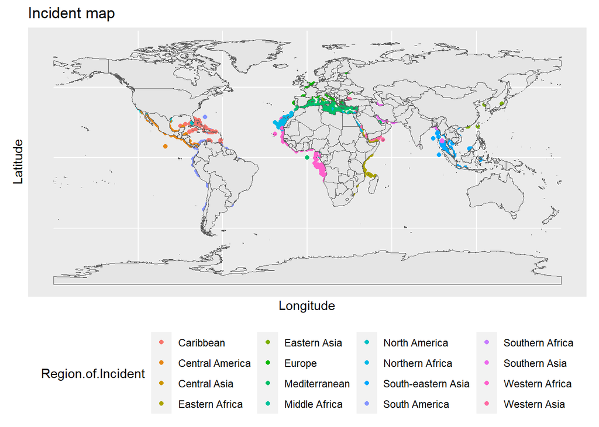

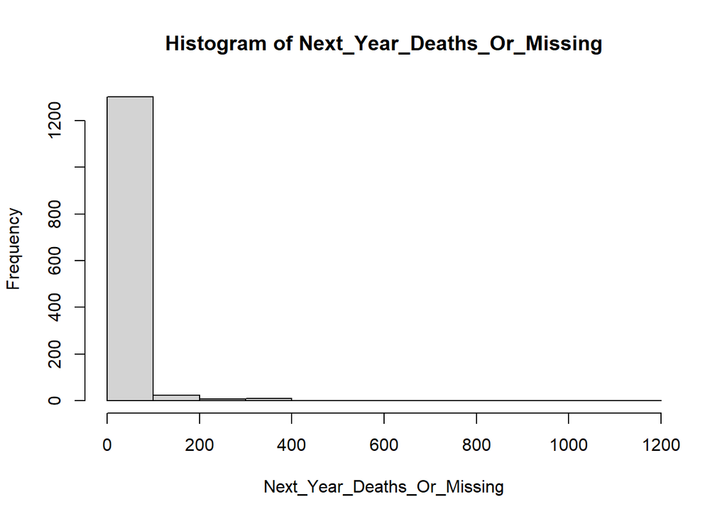

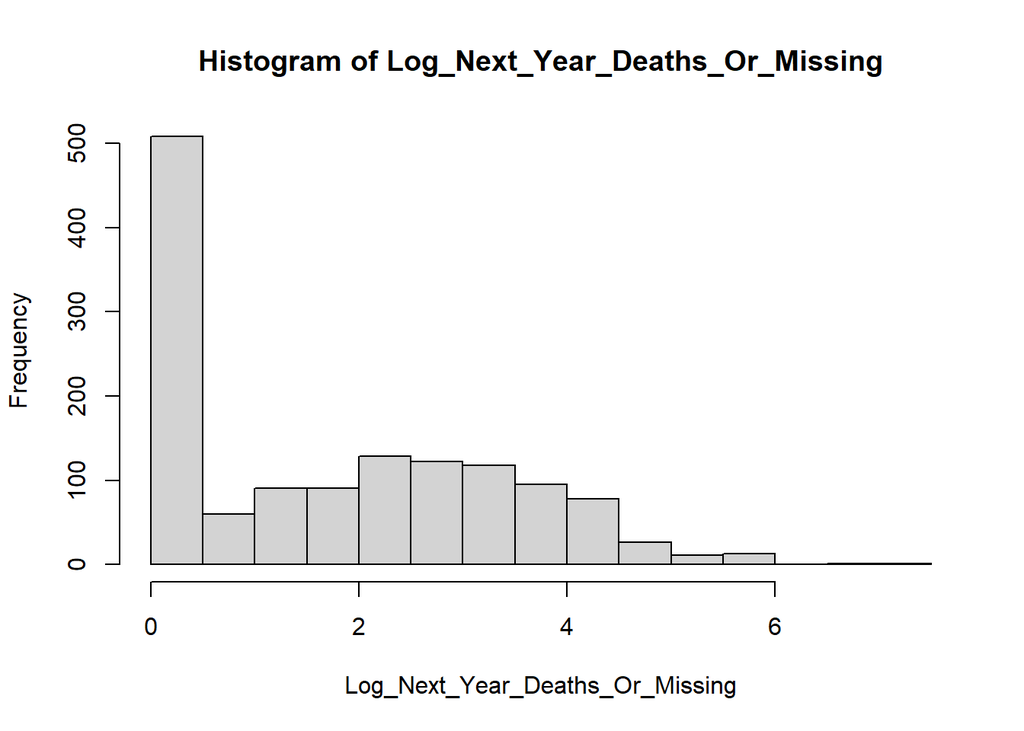

```
##
## Call:
## lm(formula = log_next_year_deaths_or_missing ~ ., data = train_data)
##
## Residuals:
##     Min      1Q  Median      3Q     Max
## -7.8769 -0.4560 -0.0080  0.5351  3.1851
##
## Coefficients: (4 not defined because of singularities)
##                                                                                                                             Estimate
## (Intercept)                                                                                                               -9.215e+01
## Region.of.IncidentCentral America                                                                                          1.159e+00
## Region.of.IncidentCentral Asia                                                                                            -1.378e+00
## Region.of.IncidentEastern Africa                                                                                           3.831e-01
## Region.of.IncidentEastern Asia                                                                                            -1.333e+00
## Region.of.IncidentEurope                                                                                                   4.820e-01
## Region.of.IncidentMediterranean                                                                                            4.752e-01
## Region.of.IncidentMiddle Africa                                                                                           -9.854e-01
## Region.of.IncidentNorth America                                                                                            1.464e+00
## Region.of.IncidentNorthern Africa                                                                                          1.484e+00
## Region.of.IncidentSouth-eastern Asia                                                                                       2.520e-02
## Region.of.IncidentSouth America                                                                                           -5.185e-01
## Region.of.IncidentSouthern Africa                                                                                         -1.310e+00
## Region.of.IncidentSouthern Asia                                                                                            2.056e-01
## Region.of.IncidentWestern Africa                                                                                           6.280e-01
## Region.of.IncidentWestern Asia                                                                                             5.345e-01
## Reported.MonthAugust                                                                                                       1.833e-01
## Reported.MonthDecember                                                                                                    -1.745e-02
## Reported.MonthFebruary                                                                                                    -3.512e-02
## Reported.MonthJanuary                                                                                                      1.757e-01
## Reported.MonthJuly                                                                                                         3.544e-02
## Reported.MonthJune                                                                                                         1.404e-01
## Reported.MonthMarch                                                                                                        9.839e-03
## Reported.MonthMay                                                                                                         -2.771e-02
## Reported.MonthNovember                                                                                                    -3.437e-01
## Reported.MonthOctober                                                                                                      1.649e-01
## Reported.MonthSeptember                                                                                                    4.881e-02
## Incident.year                                                                                                              4.637e-02
## dead_or_missing                                                                                                            4.757e-05
## males                                                                                                                     -1.653e-02
```

[output cut: 210 more lines]

```
## `Drowning,Harsh environmental conditions / lack of adequate shelter, food, water`
## `Drowning,Vehicle accident / death linked to hazardous transport`
## `Harsh environmental conditions / lack of adequate shelter, food, water,Sickness / lack of access to adequate healthcare` **
## `Harsh environmental conditions / lack of adequate shelter, food, water,Mixed or unknown`
## `Mixed or unknown,Vehicle accident / death linked to hazardous transport,Violence`                                        *
## `Harsh environmental conditions / lack of adequate shelter, food, water,Violence`
## `Drowning,Sickness / lack of access to adequate healthcare`
## next_year_deaths_or_missing                                                                                               ***
## month_n
## ---
## Signif. codes:  0 '***' 0.001 '**' 0.01 '*' 0.05 '.' 0.1 ' ' 1
##
## Residual standard error: 0.9614 on 1030 degrees of freedom
## Multiple R-squared:  0.6776, Adjusted R-squared:  0.6638
## F-statistic:  49.2 on 44 and 1030 DF,  p-value: < 2.2e-16
```

```
## Start:  AIC=183.57
## log_next_year_deaths_or_missing ~ Region.of.Incident + Reported.Month +
##     Incident.year + dead_or_missing + males + females + children +
##     `Mixed or unknown` + Violence + `Harsh environmental conditions / lack of adequate shelter, food, water` +
##     Drowning + `Vehicle accident / death linked to hazardous transport` +
##     `Sickness / lack of access to adequate healthcare` + `Accidental death` +
##     `Drowning,Mixed or unknown` + `Drowning,Harsh environmental conditions / lack of adequate shelter, food, water` +
##     `Drowning,Vehicle accident / death linked to hazardous transport` +
##     `Harsh environmental conditions / lack of adequate shelter, food, water,Sickness / lack of access to adequate healthcare` +
##     `Harsh environmental conditions / lack of adequate shelter, food, water,Mixed or unknown` +
##     `Mixed or unknown,Vehicle accident / death linked to hazardous transport,Violence` +
##     `Harsh environmental conditions / lack of adequate shelter, food, water,Violence` +
##     `Drowning,Sickness / lack of access to adequate healthcare` +
##     next_year_deaths_or_missing + month_n
##
##
## Step:  AIC=183.57
## log_next_year_deaths_or_missing ~ Region.of.Incident + Reported.Month +
##     Incident.year + dead_or_missing + males + females + children +
##     `Mixed or unknown` + Violence + `Harsh environmental conditions / lack of adequate shelter, food, water` +
##     Drowning + `Vehicle accident / death linked to hazardous transport` +
##     `Sickness / lack of access to adequate healthcare` + `Accidental death` +
##     `Drowning,Mixed or unknown` + `Drowning,Harsh environmental conditions / lack of adequate shelter, food, water` +
##     `Drowning,Vehicle accident / death linked to hazardous transport` +
##     `Harsh environmental conditions / lack of adequate shelter, food, water,Sickness / lack of access to adequate healthcare` +
##     `Harsh environmental conditions / lack of adequate shelter, food, water,Mixed or unknown` +
##     `Mixed or unknown,Vehicle accident / death linked to hazardous transport,Violence` +
##     `Harsh environmental conditions / lack of adequate shelter, food, water,Violence` +
##     `Drowning,Sickness / lack of access to adequate healthcare` +
##     next_year_deaths_or_missing
##
##
## Step:  AIC=183.57
## log_next_year_deaths_or_missing ~ Region.of.Incident + Reported.Month +
##     Incident.year + dead_or_missing + males + females + children +
##     `Mixed or unknown` + Violence + `Harsh environmental conditions / lack of adequate shelter, food, water` +
##     Drowning + `Vehicle accident / death linked to hazardous transport` +
##     `Sickness / lack of access to adequate healthcare` + `Accidental death` +
##     `Drowning,Mixed or unknown` + `Drowning,Harsh environmental conditions / lack of adequate shelter, food, water` +
##     `Drowning,Vehicle accident / death linked to hazardous transport` +
```

[output cut: 1087 more lines]

```
## - Region.of.Incident                                                                                                           904.47
##                                                                                                                                 RSS
## <none>                                                                                                                       999.45
## - `Accidental death`                                                                                                        1006.74
## - Incident.year                                                                                                             1008.37
## - `Harsh environmental conditions / lack of adequate shelter, food, water,Sickness / lack of access to adequate healthcare` 1010.10
## - next_year_deaths_or_missing                                                                                               1304.04
## - Region.of.Incident                                                                                                        1903.92
##                                                                                                                                AIC
## <none>                                                                                                                       61.26
## - `Accidental death`                                                                                                         62.10
## - Incident.year                                                                                                              63.83
## - `Harsh environmental conditions / lack of adequate shelter, food, water,Sickness / lack of access to adequate healthcare`  65.68
## - next_year_deaths_or_missing                                                                                               340.26
## - Region.of.Incident                                                                                                        649.36
```

```
##
## Call: gam(formula = log_next_year_deaths_or_missing ~ ., data = train_data)
## Deviance Residuals:
##      Min       1Q   Median       3Q      Max
## -7.87694 -0.45597 -0.00801  0.53505  3.18513
##
## (Dispersion Parameter for gaussian family taken to be 0.9243)
##
##     Null Deviance: 2953.164 on 1074 degrees of freedom
## Residual Deviance: 952.0783 on 1030 degrees of freedom
## AIC: 3012.182
##
## Number of Local Scoring Iterations: 2
##
## Anova for Parametric Effects
##                                                                                                                             Df
## Region.of.Incident                                                                                                          15
## Reported.Month                                                                                                              11
## Incident.year                                                                                                                1
## dead_or_missing                                                                                                              1
## males                                                                                                                        1
## females                                                                                                                      1
## children                                                                                                                     1
## `Mixed or unknown`                                                                                                           1
## Violence                                                                                                                     1
## `Harsh environmental conditions / lack of adequate shelter, food, water`                                                     1
## Drowning                                                                                                                     1
## `Vehicle accident / death linked to hazardous transport`                                                                     1
## `Sickness / lack of access to adequate healthcare`                                                                           1
## `Accidental death`                                                                                                           1
## `Drowning,Mixed or unknown`                                                                                                  1
## `Drowning,Harsh environmental conditions / lack of adequate shelter, food, water`                                            1
## `Harsh environmental conditions / lack of adequate shelter, food, water,Sickness / lack of access to adequate healthcare`    1
## `Harsh environmental conditions / lack of adequate shelter, food, water,Mixed or unknown`                                    1
## `Mixed or unknown,Vehicle accident / death linked to hazardous transport,Violence`                                           1
## next_year_deaths_or_missing                                                                                                  1
## Residuals                                                                                                                 1030
##                                                                                                                            Sum Sq
## Region.of.Incident                                                                                                        1607.65
## Reported.Month                                                                                                              24.88
```

[output cut: 94 more lines]

```
## Violence
## `Harsh environmental conditions / lack of adequate shelter, food, water`                                                  .
## Drowning                                                                                                                  *
## `Vehicle accident / death linked to hazardous transport`
## `Sickness / lack of access to adequate healthcare`                                                                        **
## `Accidental death`                                                                                                        ***
## `Drowning,Mixed or unknown`
## `Drowning,Harsh environmental conditions / lack of adequate shelter, food, water`
## `Harsh environmental conditions / lack of adequate shelter, food, water,Sickness / lack of access to adequate healthcare` ***
## `Harsh environmental conditions / lack of adequate shelter, food, water,Mixed or unknown`
## `Mixed or unknown,Vehicle accident / death linked to hazardous transport,Violence`                                        .
## next_year_deaths_or_missing                                                                                               ***
## Residuals
## ---
## Signif. codes:  0 '***' 0.001 '**' 0.01 '*' 0.05 '.' 0.1 ' ' 1
```

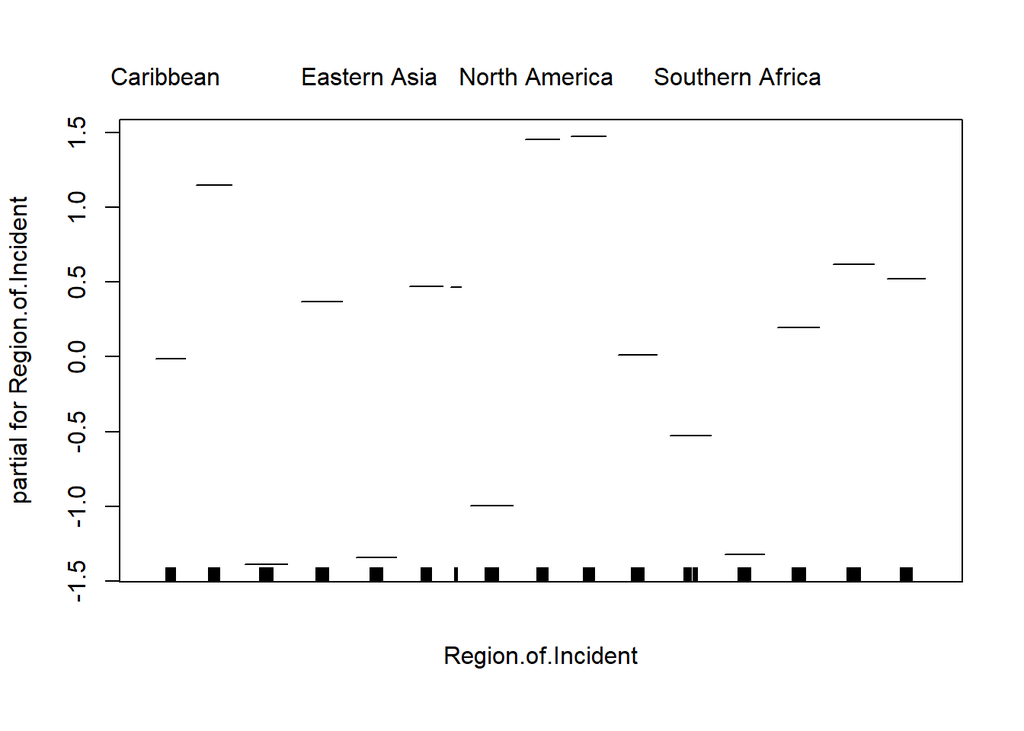

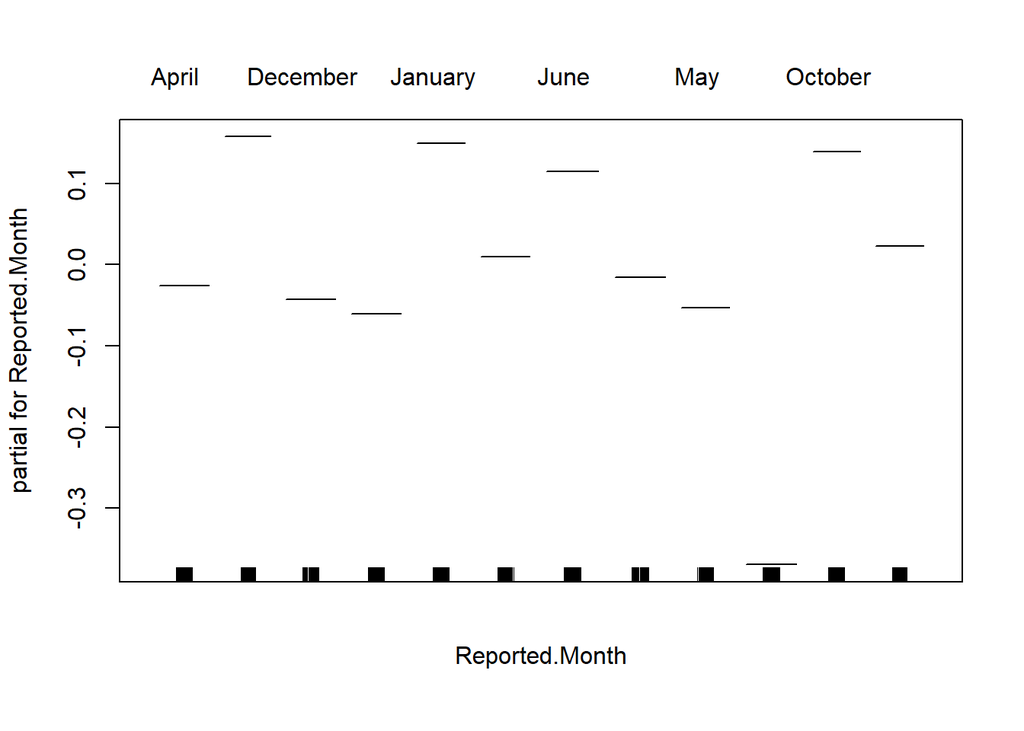

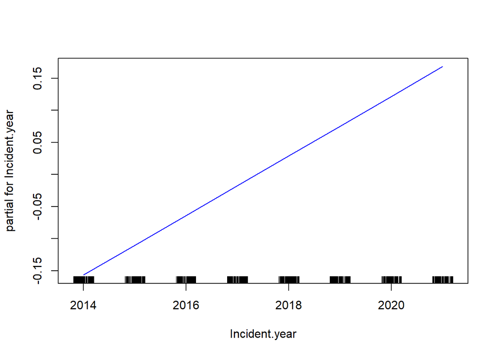

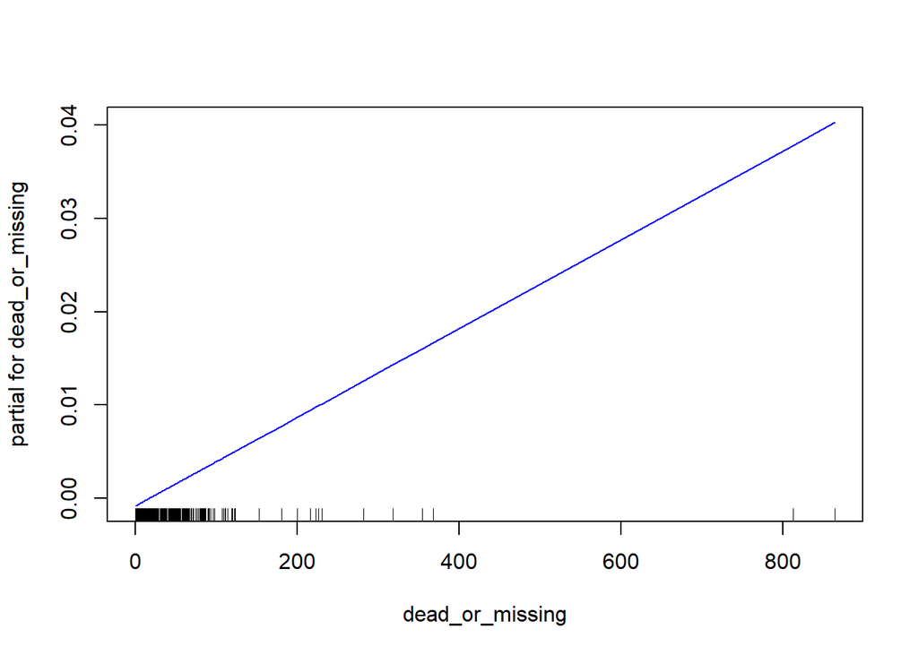

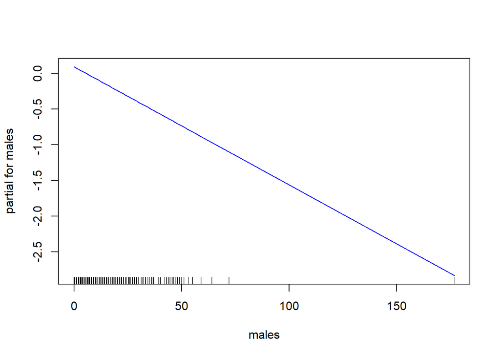

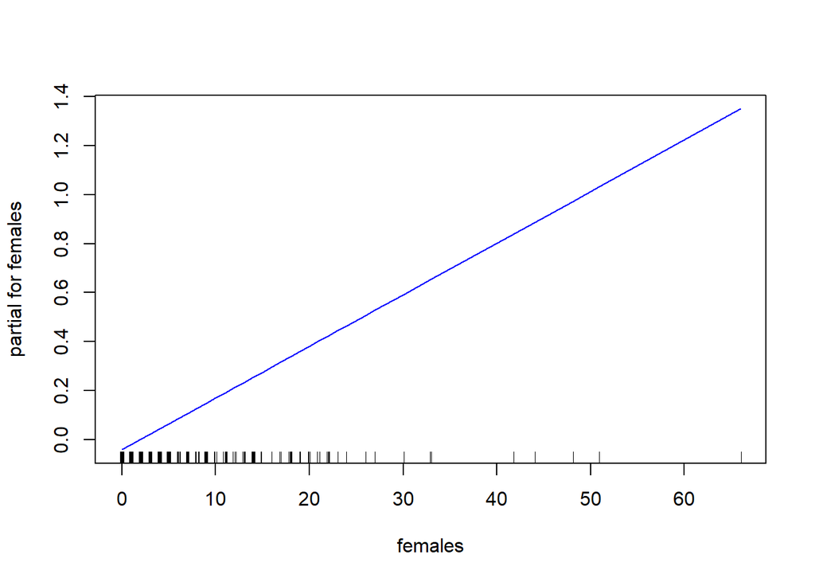

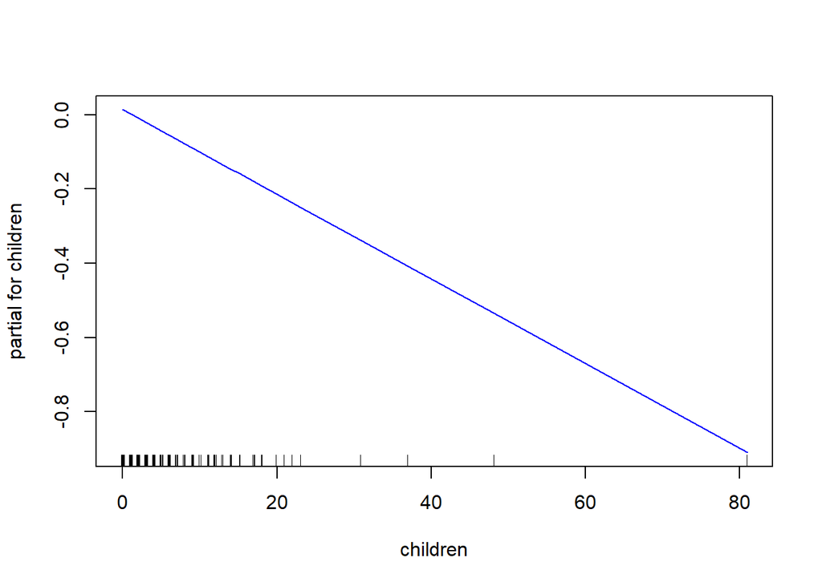

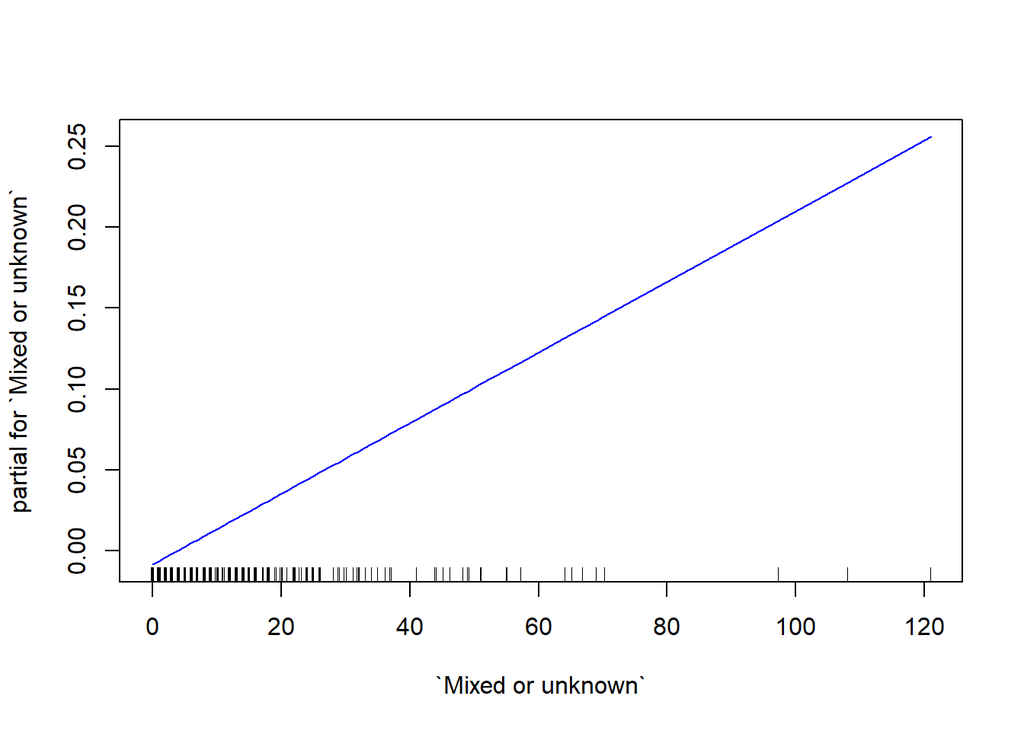

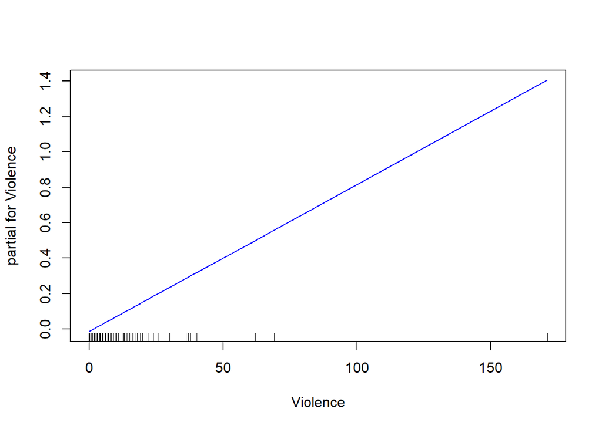

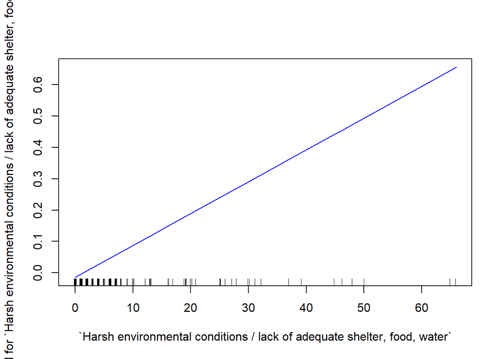

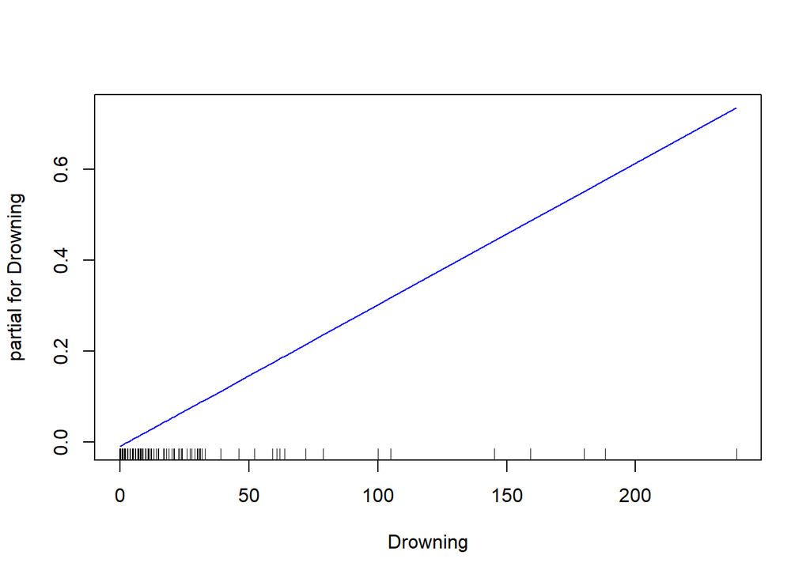

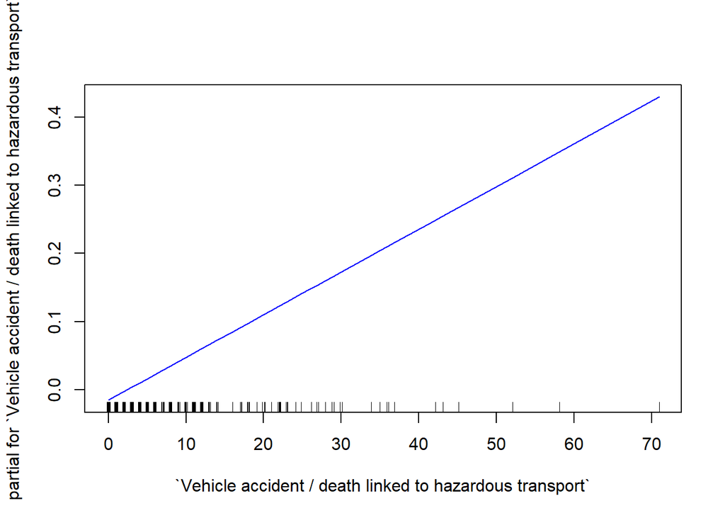

[12 more figures not shown]

```
##                 ME     RMSE      MAE MPE MAPE
## Test set 0.3398624 69.20721 12.64979 NaN  Inf
```

```
##                ME     RMSE      MAE MPE MAPE
## Test set 1.262259 81.84552 13.25209 NaN  Inf
```

```
##                 ME     RMSE      MAE MPE MAPE
## Test set 0.3398624 69.20721 12.64979 NaN  Inf
```

```
##                ME     RMSE      MAE MPE MAPE
## Test set 16.06788 36.01834 16.06788 Inf  Inf
```

```
##          1          1          1
## 18.4575426 18.4575426  0.5124534
```

#### Migrant Region of Origin:

```
## Latin America / Caribbean (P)                       Unknown
##                          1930                          1595
##        Sub-Saharan Africa (P)               Central America
##                          1462                          1402
##                 Southern Asia            Eastern Africa (P)
##                          1391                          1062
##                  Western Asia               Northern Africa
##                           395                           386
##                 South America   Western / Southern Asia (P)
##                           276                           243
```

#### Leading Cause of Death:

```
##                                                                                                        Mixed or unknown
##                                                                                                                    2932
##                                                                                                                Drowning
##                                                                                                                    2877
##                                                                  Vehicle accident / death linked to hazardous transport
##                                                                                                                    1816
##                                                  Harsh environmental conditions / lack of adequate shelter, food, water
##                                                                                                                    1206
##                                                                                                                Violence
##                                                                                                                    1101
##                                                                        Sickness / lack of access to adequate healthcare
##                                                                                                                    1007
##                                                                                                        Accidental death
##                                                                                                                     433
##                                         Drowning,Harsh environmental conditions / lack of adequate shelter, food, water
##                                                                                                                       5
##                                                                                               Drowning,Mixed or unknown
##                                                                                                                       4
## Harsh environmental conditions / lack of adequate shelter, food, water,Sickness / lack of access to adequate healthcare
##                                                                                                                       3
```

#### Location With Highest reported Death

```
##                                                                                                     (Other)
##                                                                                                        7378
## Pima Country Office of the Medical Examiner jurisdiction, Arizona, USA (see coordinates for exact location)
##                                                                                                        1061
##  Pima County Office of the Medical Examiner jurisdiction, Arizona, USA (see coordinates for exact location)
##                                                                                                         290
##                                                                     Reported at Milak border crossing, Iran
##                                                                                                         200
##                                                                                               Agadez, Niger
##                                                                                                         121
##                                                                                        Sahara desert, Libya
##                                                                                                         116
##                                                                                                Sabha, Libya
##                                                                                                         103
##                                                               Unspecified location in Tehran province, Iran
##                                                                                                          84
##                                                Unspecified location in Shiraz district, Fars province, Iran
##                                                                                                          73
##                                                            Unspecified location in the Sahara desert, Libya
##                                                                                                          71
```

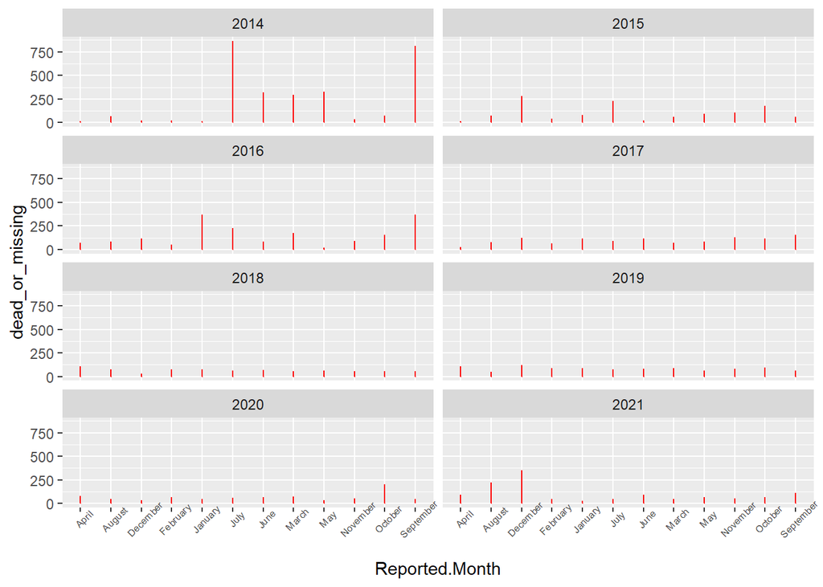

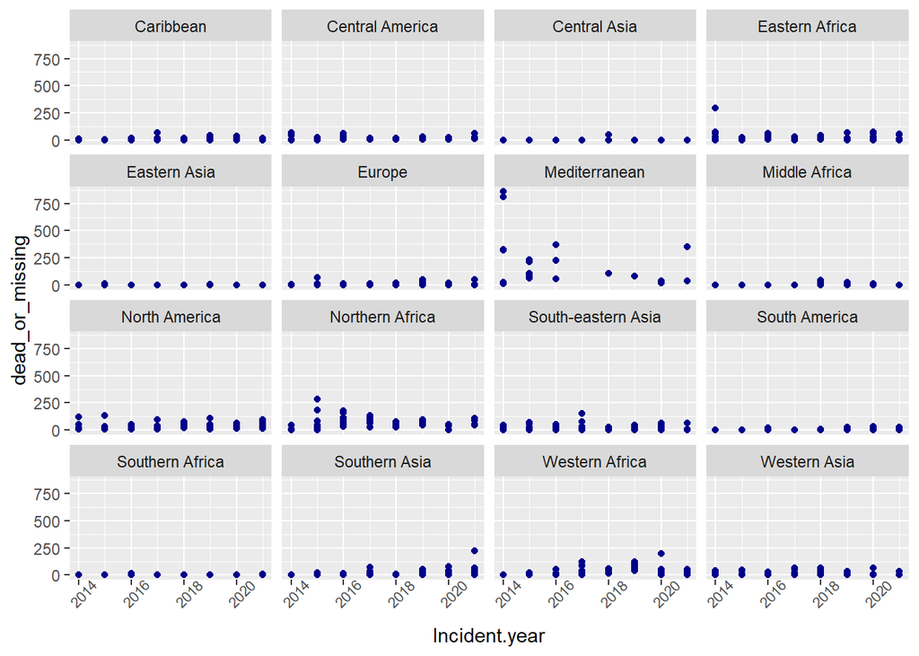

```
## [1] "sf"         "data.frame"
```

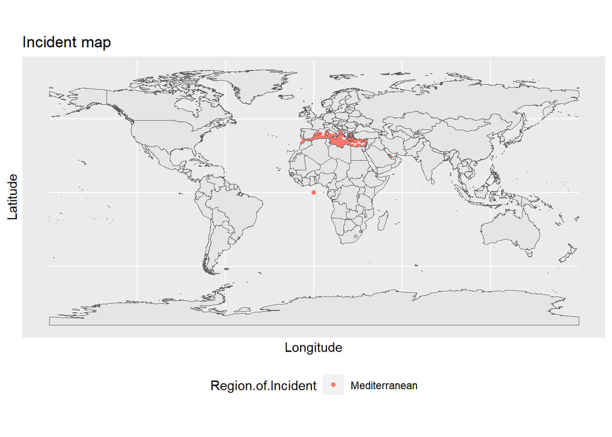

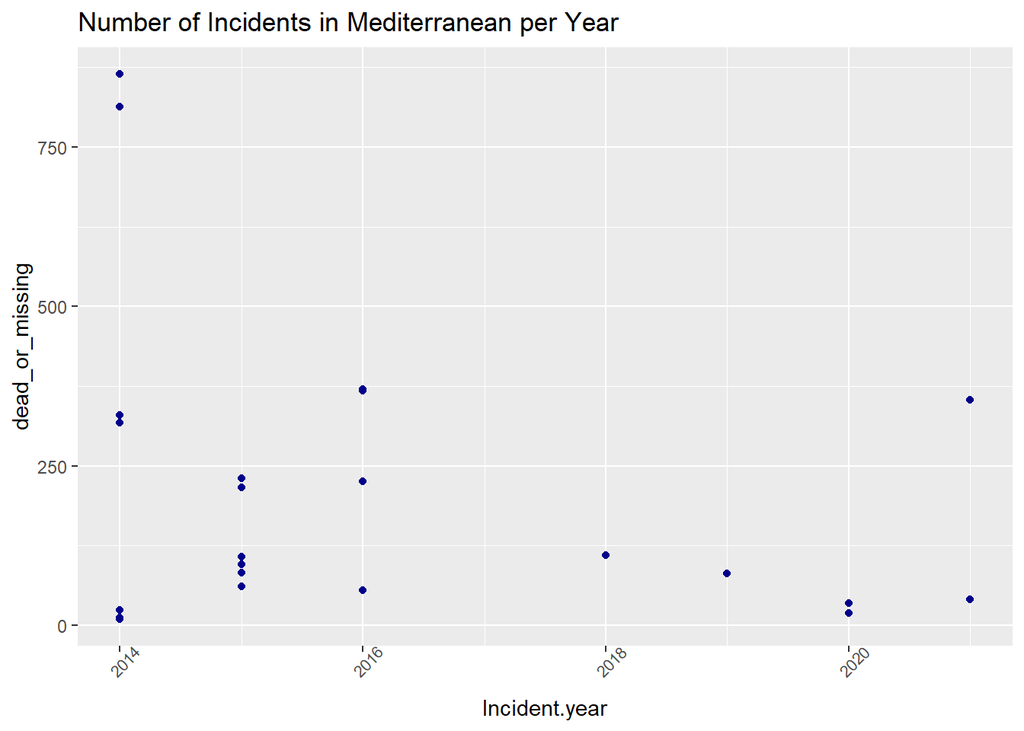

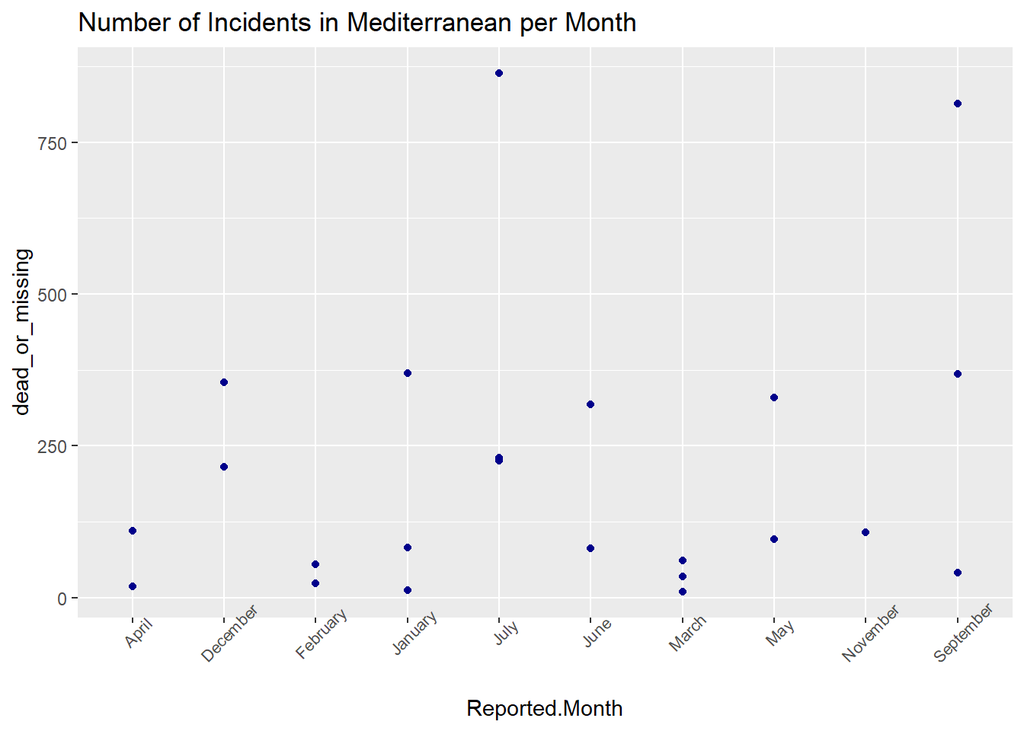

```
## Using  as id variables
```

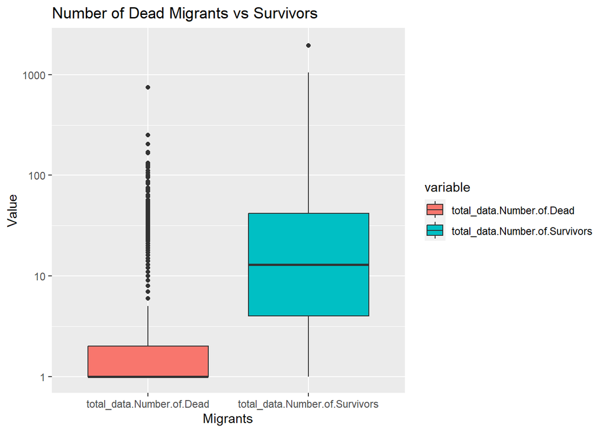

Total Dead or Missing:

```
## [1] 22956
```

Total Survivors:

```
## [1] 77641
```

```
## Using  as id variables
```

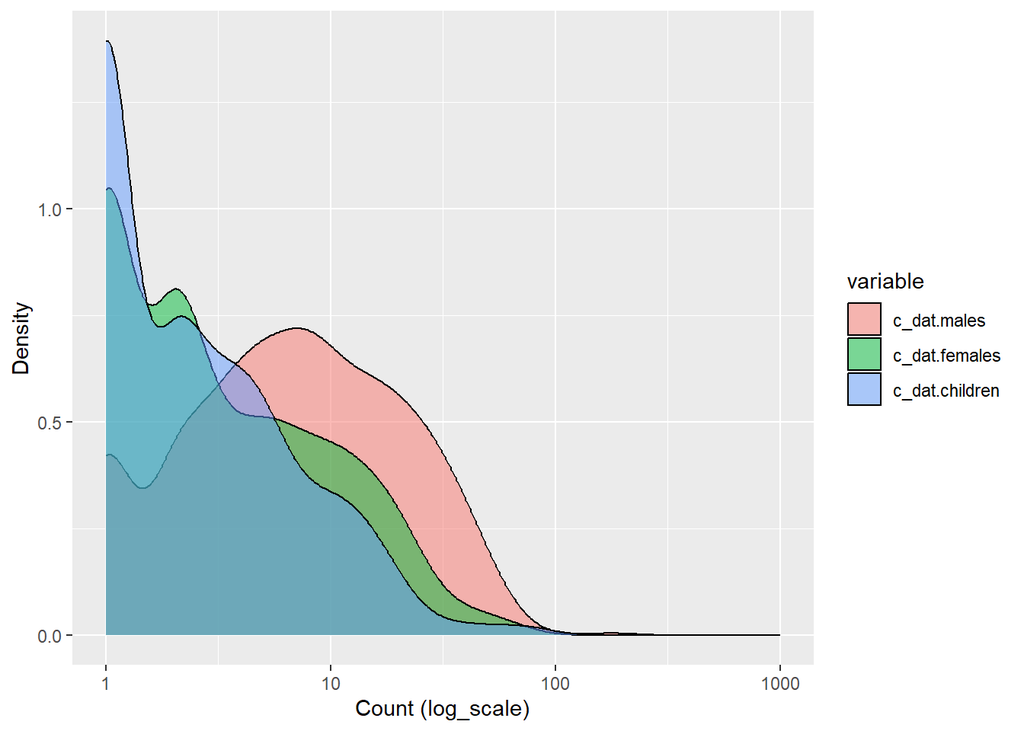

For our initial clustering lets try to fit four clusters to the data. To run K-means on our data we use the `kmeans()` function. The parameters we need to set for the K-means algorithm are:

- x - The data we want the algorithm to cluster
- centers - The number of clusters to generate.
- itermax - The number of iterations to let k-means perform
- nstart - The number of starts to try for K-means. Remember K-means may not converge to the optimal solution from a single start point. Therefore we may want to try multiple start points.

```
## [1] 25
```

```
## [1] 22848
```

The results of our clustering is stored in `fit_1`. We can extract the clusters and center values for this as follows:

Lets first check how many samples have ended up in each cluster:

```
##    1    2    3    4
## 1189  142    1   12
```

```
## Cluster 1 migrants:
```

```
##      Region.of.Incident Reported.Month Incident.year
## 1         North America        January          2014
## 2                Europe        January          2014
## 3         Mediterranean        January          2014
## 4             Caribbean        January          2014
## 5    South-eastern Asia        January          2014
## 6         Southern Asia        January          2014
## 7        Eastern Africa        January          2014
## 8       Central America        January          2014
## 9       Northern Africa        January          2014
## 10         Eastern Asia        January          2014
## 11         Western Asia        January          2014
## 12       Western Africa        January          2014
## 13        South America        January          2014
## 14      Southern Africa        January          2014
```

[output cut: 1175 more lines]

```
##      Region.of.Incident Reported.Month Incident.year
## 83        Mediterranean           June          2014
## 120     Central America         August          2014
## 129       North America      September          2014
## 201     Northern Africa        January          2015
## 259       Mediterranean            May          2015
## 305       North America         August          2015
## 306              Europe         August          2015
## 345     Northern Africa        October          2015
## 361     Northern Africa       November          2015
## 369       North America       December          2015
## 377     Northern Africa       December          2015
## 393     Northern Africa        January          2016
## 425     Northern Africa          March          2016
## 441     Northern Africa          April          2016
```

[output cut: 128 more lines]

```
##      Region.of.Incident Reported.Month Incident.year
## 1462      Southern Asia         August          2021
```

```
##      Region.of.Incident Reported.Month Incident.year
## 39       Eastern Africa          March          2014
## 67        Mediterranean            May          2014
## 99        Mediterranean           July          2014
## 131       Mediterranean      September          2014
## 291       Mediterranean           July          2015
## 355       Mediterranean       November          2015
## 371       Mediterranean       December          2015
## 387       Mediterranean        January          2016
## 483       Mediterranean           July          2016
## 515       Mediterranean      September          2016
## 709  South-eastern Asia      September          2017
## 1523      Mediterranean       December          2021
```

Lets check how the center values for each of the clusters compare to each other. To make this interpret-able lets just use the overall migration values:

```
##   cluster log_next_year_deaths_or_missing        features     values
## 1       1                      -0.1344981 dead_or_missing -0.2072857
## 2       2                       1.0042324 dead_or_missing  1.0935587
## 3       3                      -1.0431775 dead_or_missing  4.3401308
## 4       4                       1.5300387 dead_or_missing  7.2364369
## 5       1                      -0.1344981           males -0.2388443
## 6       2                       1.0042324           males  1.7771928
```

```
##    cluster log_next_year_deaths_or_missing
## 59       3                      -1.0431775
## 60       4                       1.5300387
## 61       1                      -0.1344981
## 62       2                       1.0042324
## 63       3                      -1.0431775
## 64       4                       1.5300387
##                                                                                   features
## 59 Harsh.environmental.conditions...lack.of.adequate.shelter..food..water.Mixed.or.unknown
## 60 Harsh.environmental.conditions...lack.of.adequate.shelter..food..water.Mixed.or.unknown
## 61        Mixed.or.unknown.Vehicle.accident...death.linked.to.hazardous.transport.Violence
## 62        Mixed.or.unknown.Vehicle.accident...death.linked.to.hazardous.transport.Violence
## 63        Mixed.or.unknown.Vehicle.accident...death.linked.to.hazardous.transport.Violence
## 64        Mixed.or.unknown.Vehicle.accident...death.linked.to.hazardous.transport.Violence
##         values
## 59 -0.02727724
## 60 -0.02727724
## 61 -0.02727724
## 62 -0.02727724
## 63 36.63332832
## 64 -0.02727724
```

[output not shown]

[figure not shown]

### Calculate cluster number

Perhaps four is not the optimal cluster number for this dataset. Lets try a few different cluster values and view the error for each different number. Remember that the error will always decrease as we add more clusters so that we are looking for the point where the rate of improvement in performance starts to decrease.

I have found that in reality a plot this clear is rarely found and it often be best to choose the number of clusters based on the needs of the analysis. Let’s create it anyway and see what it looks like for this dataset:

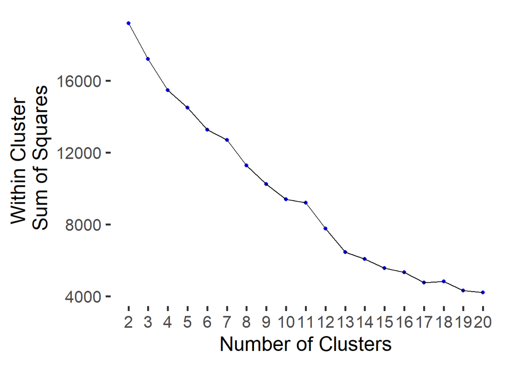

The results of our clustering is stored in `fit_2`. We can extract the clusters and center values for this as follows:

```
##   1   2   3   4   5   6   7   8
##  10 133   1   1  40 516 631  12
```

[output not shown]

```
##      Region.of.Incident Reported.Month Incident.year
## 1158      Southern Asia        January          2020
## 1174      Southern Asia       February          2020
## 1191     Eastern Africa          March          2020
## 1249      North America           July          2020
## 1254      Southern Asia           July          2020
## 1270      Southern Asia         August          2020
## 1302      Southern Asia        October          2020
## 1318      Southern Asia       November          2020
## 1334      Southern Asia       December          2020
## 1513    Northern Africa       November          2021
```

```
##      Region.of.Incident Reported.Month Incident.year
## 83        Mediterranean           June          2014
## 113       North America         August          2014
## 120     Central America         August          2014
## 129       North America      September          2014
## 152     Central America        October          2014
## 201     Northern Africa        January          2015
## 259       Mediterranean            May          2015
## 305       North America         August          2015
## 306              Europe         August          2015
## 321       North America      September          2015
## 329     Northern Africa      September          2015
## 361     Northern Africa       November          2015
## 369       North America       December          2015
## 393     Northern Africa        January          2016
```

[output cut: 119 more lines]

```
##      Region.of.Incident Reported.Month Incident.year
## 1462      Southern Asia         August          2021
```

```
##      Region.of.Incident Reported.Month Incident.year
## 1369    Northern Africa       February          2021
```

```
##      Region.of.Incident Reported.Month Incident.year
## 345     Northern Africa        October          2015
## 377     Northern Africa       December          2015
## 425     Northern Africa          March          2016
## 476      Western Africa           June          2016
## 537     Northern Africa        October          2016
## 569     Northern Africa       December          2016
## 652      Western Africa            May          2017
## 681     Northern Africa           July          2017
## 684      Western Africa           July          2017
## 697     Northern Africa         August          2017
## 713     Northern Africa      September          2017
## 729     Northern Africa        October          2017
## 732      Western Africa        October          2017
## 745     Northern Africa       November          2017
```

[output cut: 26 more lines]

```
##      Region.of.Incident Reported.Month Incident.year
## 1         North America        January          2014
## 3         Mediterranean        January          2014
## 5    South-eastern Asia        January          2014
## 7        Eastern Africa        January          2014
## 9       Northern Africa        January          2014
## 17        North America       February          2014
## 19        Mediterranean       February          2014
## 25      Northern Africa       February          2014
## 26         Eastern Asia       February          2014
## 27         Western Asia       February          2014
## 33        North America          March          2014
## 35        Mediterranean          March          2014
## 37   South-eastern Asia          March          2014
## 40      Central America          March          2014
```

[output cut: 502 more lines]

```
##      Region.of.Incident Reported.Month Incident.year
## 2                Europe        January          2014
## 4             Caribbean        January          2014
## 6         Southern Asia        January          2014
## 8       Central America        January          2014
## 10         Eastern Asia        January          2014
## 11         Western Asia        January          2014
## 12       Western Africa        January          2014
## 13        South America        January          2014
## 14      Southern Africa        January          2014
## 15        Middle Africa        January          2014
## 16         Central Asia        January          2014
## 18               Europe       February          2014
## 20            Caribbean       February          2014
## 21   South-eastern Asia       February          2014
```

[output cut: 617 more lines]

```
##      Region.of.Incident Reported.Month Incident.year
## 39       Eastern Africa          March          2014
## 67        Mediterranean            May          2014
## 99        Mediterranean           July          2014
## 131       Mediterranean      September          2014
## 291       Mediterranean           July          2015
## 355       Mediterranean       November          2015
## 371       Mediterranean       December          2015
## 387       Mediterranean        January          2016
## 483       Mediterranean           July          2016
## 515       Mediterranean      September          2016
## 709  South-eastern Asia      September          2017
## 1523      Mediterranean       December          2021
```

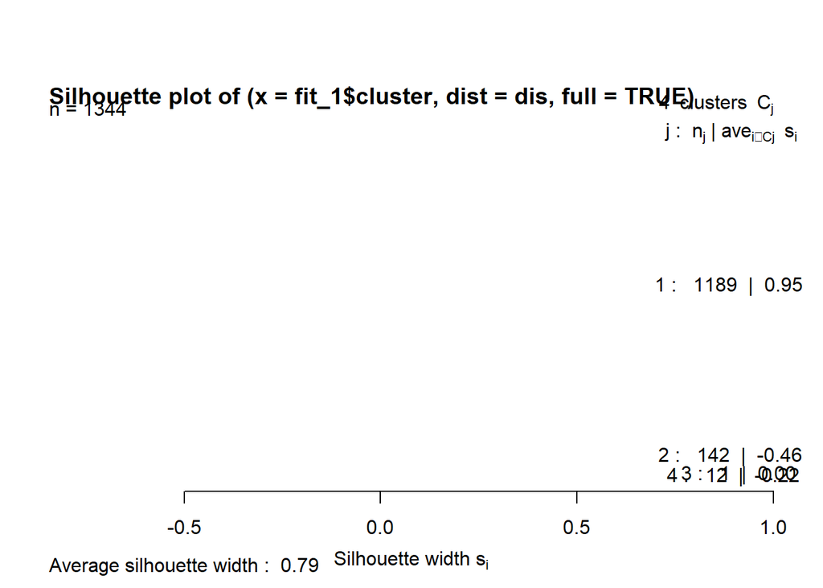

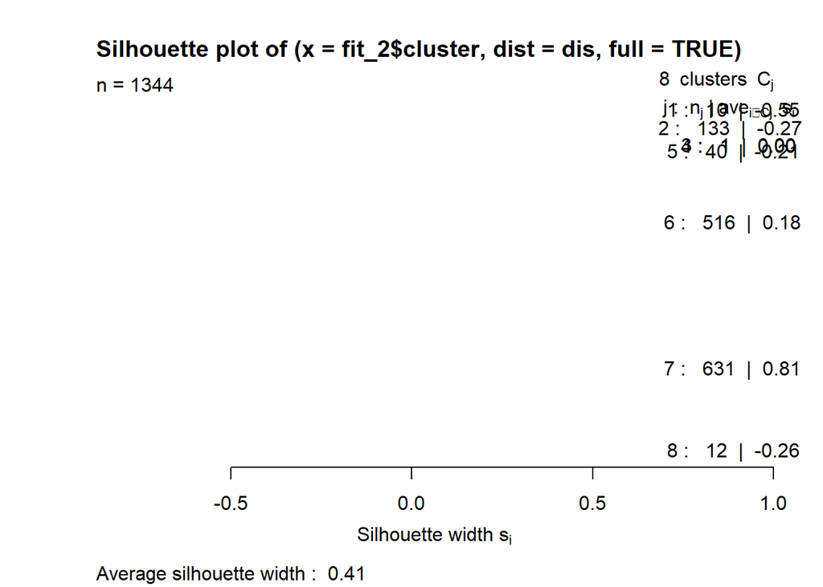

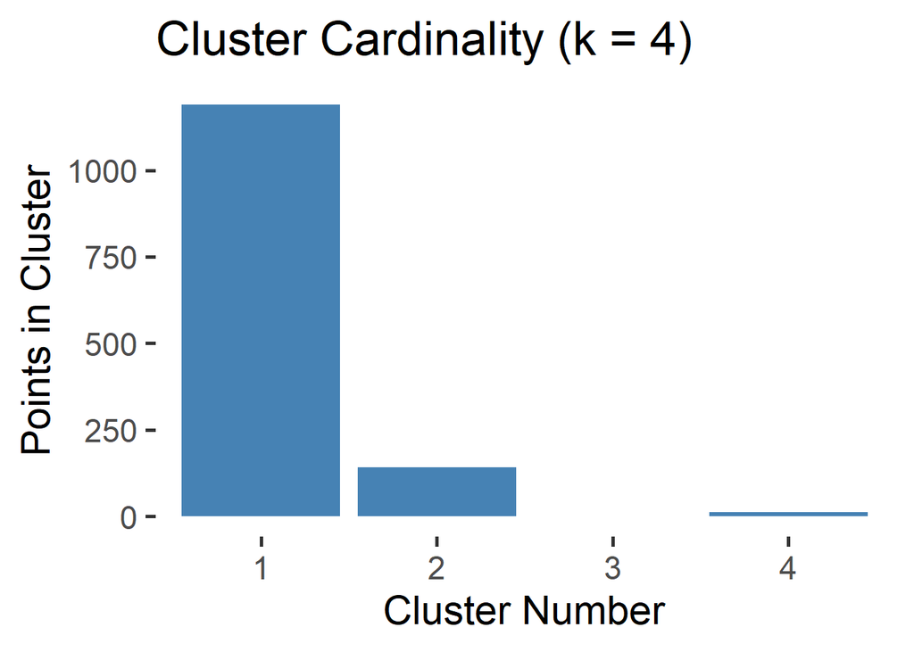

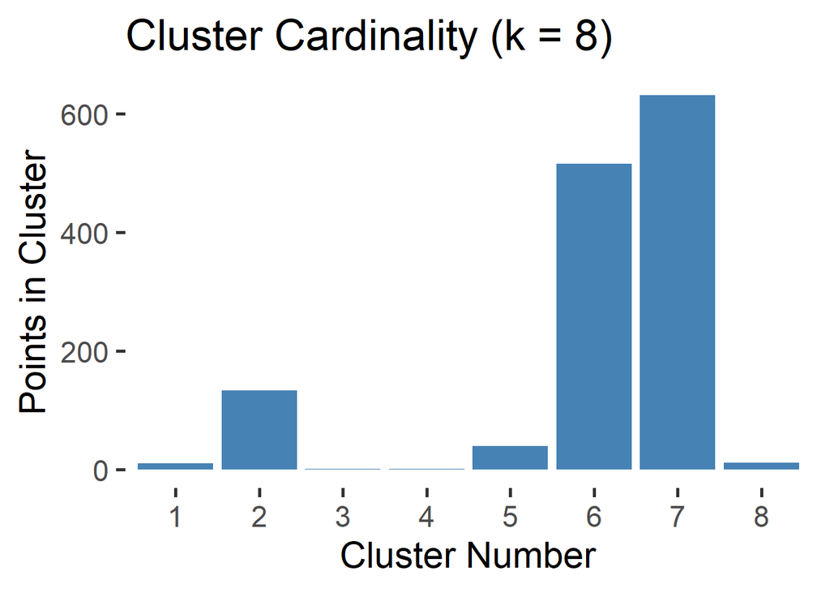

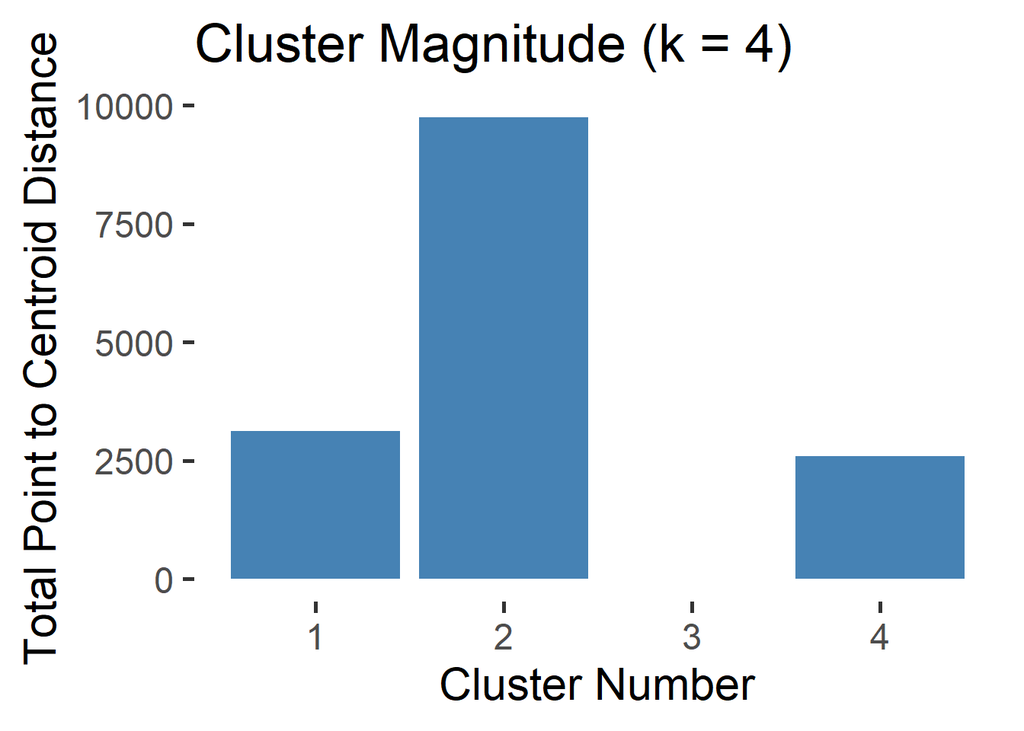

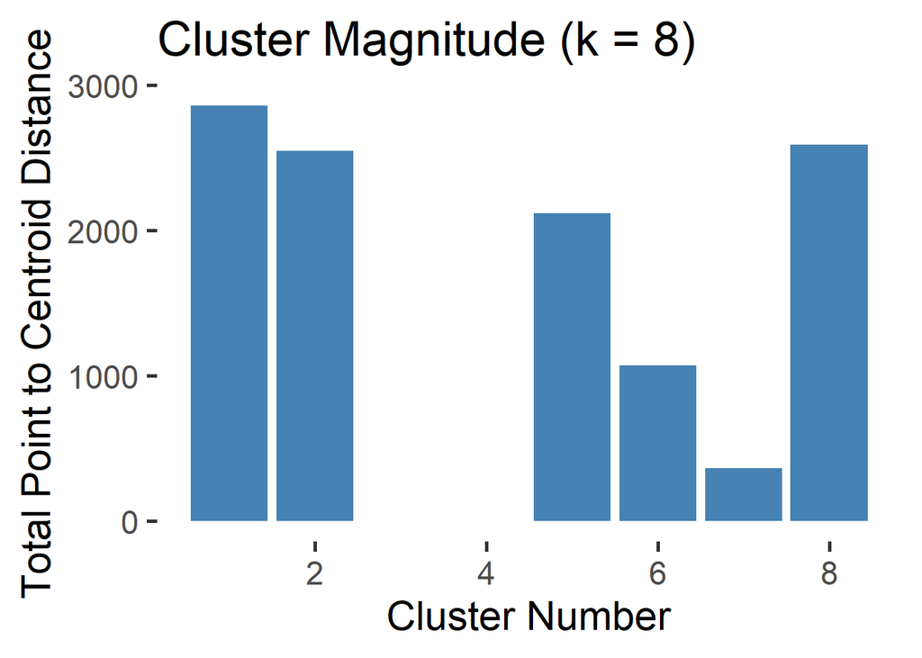

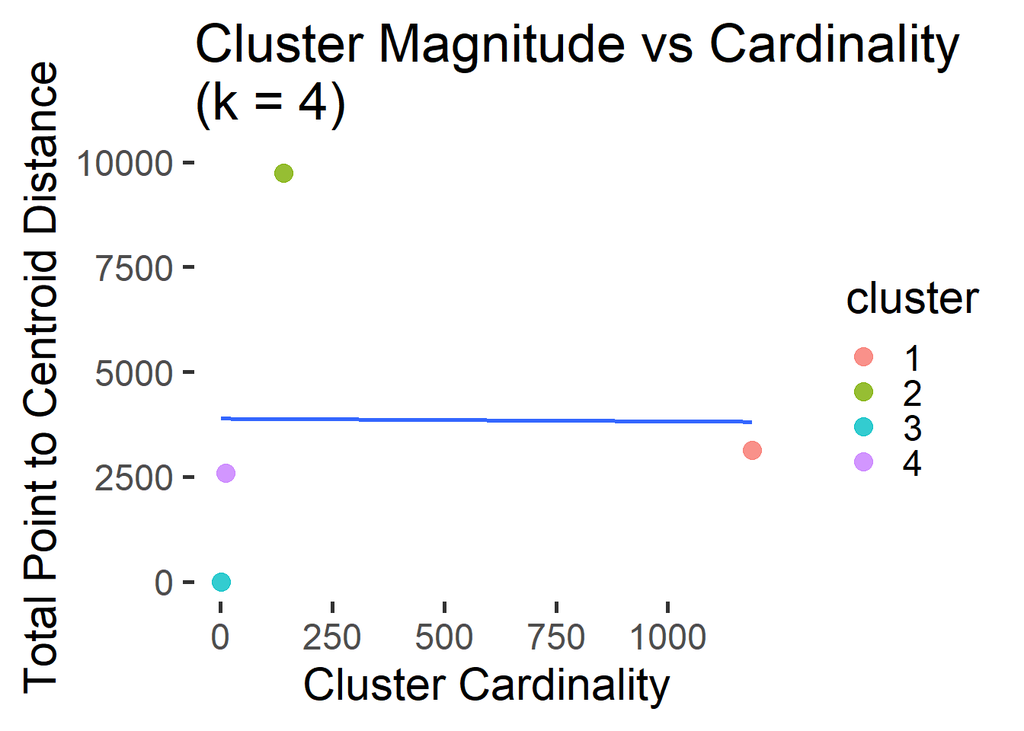

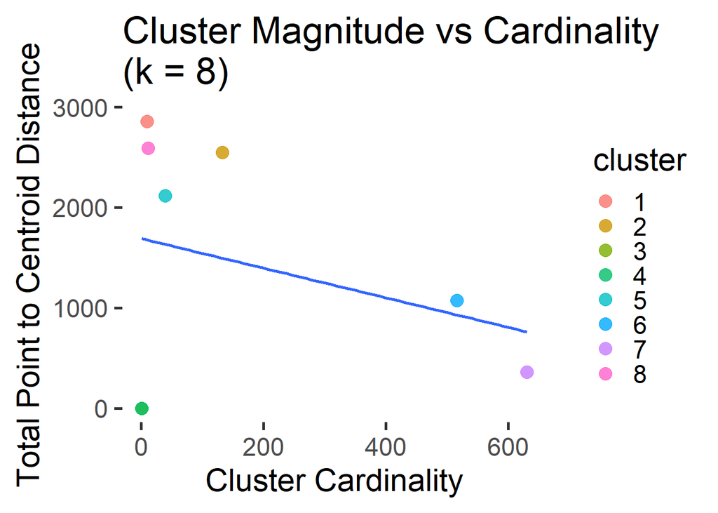

```
## When K = 4:
```

```
## [1] migrants cluster
## <0 rows> (or 0-length row.names)
```

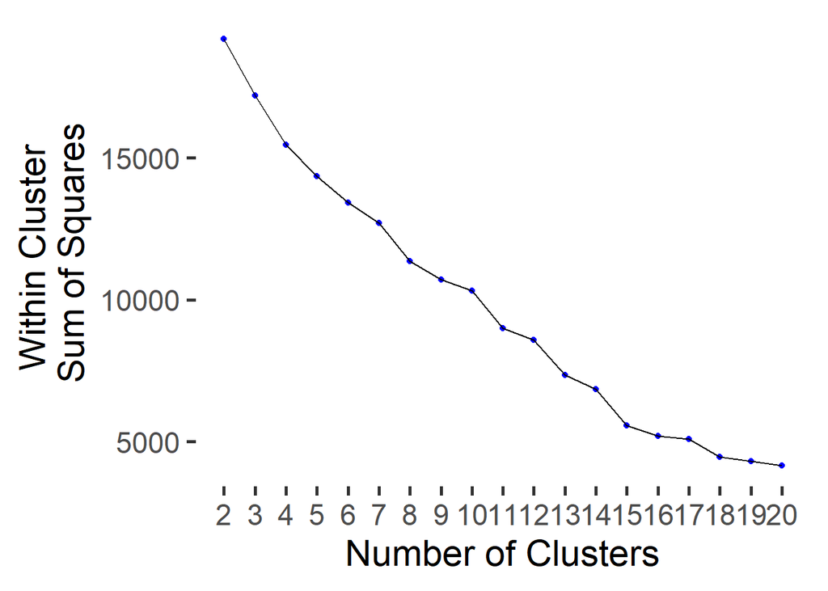

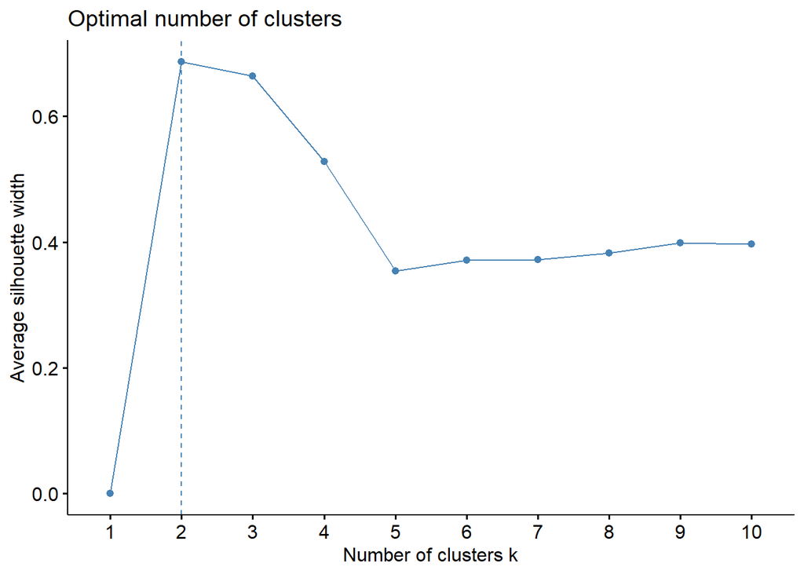

[output not shown]

[output cut: 556 more lines]

[output not shown]

```
## Clustering Gap statistic ["clusGap"] from call:
## clusGap(x = off_dat, FUNcluster = kmeans, K.max = 20, B = 50, nstart = 25)
## B=50 simulated reference sets, k = 1..20; spaceH0="scaledPCA"
##  --> Number of clusters (method 'firstmax'): 2
##           logW   E.logW      gap      SE.sim
##  [1,] 7.052773 9.590918 2.538146 0.004062476
##  [2,] 6.886638 9.530119 2.643481 0.004302090
##  [3,] 6.865257 9.491050 2.625793 0.004188531
##  [4,] 6.824777 9.459324 2.634547 0.004047118
##  [5,] 6.665256 9.436237 2.770981 0.004055047
##  [6,] 6.623180 9.416032 2.792852 0.003962438
##  [7,] 6.611656 9.398386 2.786730 0.003830456
##  [8,] 6.564706 9.382197 2.817492 0.003705225
##  [9,] 6.529765 9.368034 2.838268 0.003427485
## [10,] 6.508764 9.355547 2.846783 0.003380341
## [11,] 6.483163 9.344707 2.861544 0.003408421
## [12,] 6.438065 9.334609 2.896544 0.003407477
## [13,] 6.421430 9.324964 2.903534 0.003342172
## [14,] 6.380586 9.316071 2.935486 0.003430635
## [15,] 6.363931 9.307518 2.943586 0.003211417
## [16,] 6.328244 9.299365 2.971121 0.003276275
## [17,] 6.302414 9.292651 2.990236 0.003143062
## [18,] 6.281325 9.286044 3.004719 0.003221522
## [19,] 6.252066 9.279798 3.027732 0.003032128
## [20,] 6.225327 9.273913 3.048586 0.003091982
```

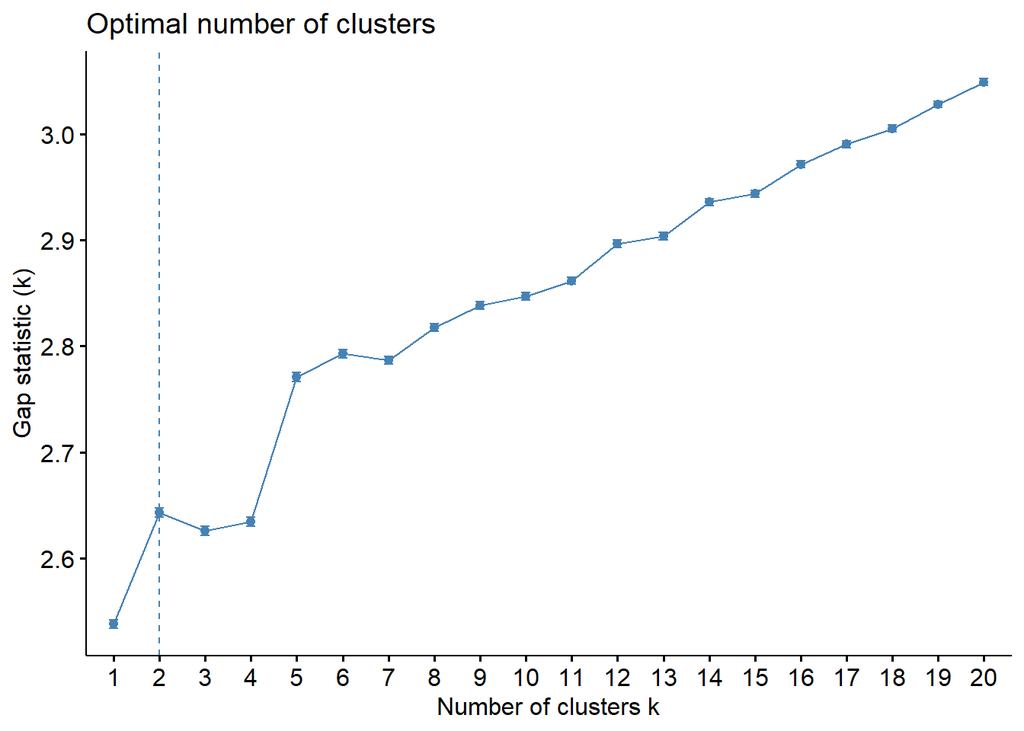

```
##   1   2   3   4   5   6
## 114  11  12 662   1 544
```

Lets view the migrants in each cluster:

[output not shown]

```
##      Region.of.Incident Reported.Month Incident.year
## 83        Mediterranean           June          2014
## 129       North America      September          2014
## 259       Mediterranean            May          2015
## 306              Europe         August          2015
## 345     Northern Africa        October          2015
## 361     Northern Africa       November          2015
## 369       North America       December          2015
## 377     Northern Africa       December          2015
## 425     Northern Africa          March          2016
## 441     Northern Africa          April          2016
## 473     Northern Africa           June          2016
## 476      Western Africa           June          2016
## 489     Northern Africa           July          2016
## 504     Central America         August          2016
```

[output cut: 100 more lines]

```
##      Region.of.Incident Reported.Month Incident.year
## 1158      Southern Asia        January          2020
## 1174      Southern Asia       February          2020
## 1191     Eastern Africa          March          2020
## 1249      North America           July          2020
## 1254      Southern Asia           July          2020
## 1270      Southern Asia         August          2020
## 1302      Southern Asia        October          2020
## 1318      Southern Asia       November          2020
## 1334      Southern Asia       December          2020
## 1369    Northern Africa       February          2021
## 1513    Northern Africa       November          2021
```

```
##      Region.of.Incident Reported.Month Incident.year
## 39       Eastern Africa          March          2014
## 67        Mediterranean            May          2014
## 99        Mediterranean           July          2014
## 131       Mediterranean      September          2014
## 291       Mediterranean           July          2015
## 355       Mediterranean       November          2015
## 371       Mediterranean       December          2015
## 387       Mediterranean        January          2016
## 483       Mediterranean           July          2016
## 515       Mediterranean      September          2016
## 709  South-eastern Asia      September          2017
## 1523      Mediterranean       December          2021
```

```
##      Region.of.Incident Reported.Month Incident.year
## 2                Europe        January          2014
## 4             Caribbean        January          2014
## 6         Southern Asia        January          2014
## 7        Eastern Africa        January          2014
## 8       Central America        January          2014
## 10         Eastern Asia        January          2014
## 11         Western Asia        January          2014
## 12       Western Africa        January          2014
## 13        South America        January          2014
## 14      Southern Africa        January          2014
## 15        Middle Africa        January          2014
## 16         Central Asia        January          2014
## 18               Europe       February          2014
## 20            Caribbean       February          2014
```

[output cut: 648 more lines]

```
##      Region.of.Incident Reported.Month Incident.year
## 1462      Southern Asia         August          2021
```

```
##      Region.of.Incident Reported.Month Incident.year
## 1         North America        January          2014
## 3         Mediterranean        January          2014
## 5    South-eastern Asia        January          2014
## 9       Northern Africa        January          2014
## 17        North America       February          2014
## 19        Mediterranean       February          2014
## 26         Eastern Asia       February          2014
## 27         Western Asia       February          2014
## 33        North America          March          2014
## 35        Mediterranean          March          2014
## 37   South-eastern Asia          March          2014
## 40      Central America          March          2014
## 41      Northern Africa          March          2014
## 43         Western Asia          March          2014
```

[output cut: 530 more lines]

Lets look at the cluster centers and see how they compare:

```
##   cluster log_next_year_deaths_or_missing        features      values
## 1       1                       0.9927274 dead_or_missing  1.24072929
## 2       2                       1.0833948 dead_or_missing  0.46966062
## 3       3                       1.5300387 dead_or_missing  7.23643693
## 4       4                      -0.8547726 dead_or_missing -0.29651442
## 5       5                      -1.0431775 dead_or_missing  4.34013085
## 6       6                       0.7784080 dead_or_missing -0.07627616
```

```
##    cluster log_next_year_deaths_or_missing
## 91       1                       0.9927274
## 92       2                       1.0833948
## 93       3                       1.5300387
## 94       4                      -0.8547726
## 95       5                      -1.0431775
## 96       6                       0.7784080
##                                                                            features
## 91 Mixed.or.unknown.Vehicle.accident...death.linked.to.hazardous.transport.Violence
## 92 Mixed.or.unknown.Vehicle.accident...death.linked.to.hazardous.transport.Violence
## 93 Mixed.or.unknown.Vehicle.accident...death.linked.to.hazardous.transport.Violence
## 94 Mixed.or.unknown.Vehicle.accident...death.linked.to.hazardous.transport.Violence
## 95 Mixed.or.unknown.Vehicle.accident...death.linked.to.hazardous.transport.Violence
## 96 Mixed.or.unknown.Vehicle.accident...death.linked.to.hazardous.transport.Violence
##         values
## 91 -0.02727724
## 92 -0.02727724
## 93 -0.02727724
## 94 -0.02727724
## 95 36.63332832
## 96 -0.02727724
```

[output not shown]

[figure not shown]